# Binary Search

Binary Search adalah algoritma pencarian yang beroperasi pada ruang pencarian yang terurut atau monoton, berulang kali membaginya menjadi dua bagian untuk menemukan nilai target atau jawaban optimal dalam waktu logaritmik O(log N).

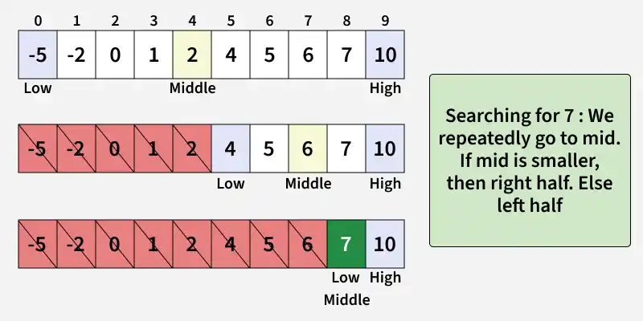

### Syarat-syarat untuk menerapkan Algoritma Binary Search pada Struktur Data

- Struktur data harus diurutkan.
- Akses ke elemen apa pun dalam struktur data harus membutuhkan waktu konstan.

### Algoritma Binary Search

- Bagilah ruang pencarian menjadi dua bagian dengan menemukan indeks tengah "mid" .
- Bandingkan bagian tengah ruang pencarian dengan key .
- Jika key ditemukan di tengah, proses dihentikan.
- Jika key tidak ditemukan di tengah, pilih bagian mana yang akan digunakan sebagai ruang pencarian berikutnya.

-> Jika key lebih kecil dari tengah, maka sisi kiri digunakan untuk pencarian berikutnya. -> Jika key lebih besar dari tengah, maka sisi kanan digunakan untuk pencarian berikutnya.

- Proses ini dilanjutkan hingga key ditemukan atau seluruh ruang pencarian habis.

### Bagaimana cara kerja Algoritma Binary Search?

Untuk memahami cara kerja Binary Search, perhatikan ilustrasi berikut:

```
Perhatikan sebuah array arr[] = {2, 5, 8, 12, 16, 23, 38, 56, 72, 91} , dan targetnya = 23 .
```

[figure not shown]

[figure not shown]

[figure not shown]

[figure not shown]

### Bagaimana Cara Mengimplementasikan Binary Search?

Hal ini dapat diimplementasikan dengan dua cara berikut.

- Algoritma Binary Search Iteratif
- Algoritma Binary Search Rekursif

**Algoritma Iteratif: Waktu O(log n) dan Ruang O(1)**

```
Di sini kita menggunakan perulangan while untuk melanjutkan proses membandingkan kunci dan membagi ruang pencarian menjadi dua bagian
```

```python
def binarySearch(arr, x):
    low = 0
    high = len(arr) - 1
    while low <= high:

        mid = low + (high - low) // 2

        # Check if x is present at mid
        if arr[mid] == x:
            return mid

        # If x is greater, ignore left half
        elif arr[mid] < x:
            low = mid + 1

        # If x is smaller, ignore right half
        else:
            high = mid - 1

    # If we reach here, then the element
    # was not present
    return -1

if __name__ == '__main__':
    arr = [2, 3, 4, 10, 40]
    x = 10

    result = binarySearch(arr, x)
    if result != -1:
        print("Element is present at index", result)
    else:
        print("Element is not present in array")
```

```
Element is present at index 3
```

**Algoritma Rekursif: Waktu O(log n) dan Ruang O(Log n)**

```
Buat fungsi rekursif dan bandingkan bagian tengah ruang pencarian dengan kunci. Berdasarkan hasilnya, kembalikan indeks tempat kunci ditemukan atau panggil fungsi rekursif untuk ruang pencarian berikutnya.
```

```python
# A recursive binary search function. It returns
# location of x in given array arr[low..high] is present,
# otherwise -1
def binarySearch(arr, low, high, x):

    # Check base case
    if high >= low:

        mid = low + (high - low) // 2

        # If element is present at the middle itself
        if arr[mid] == x:
            return mid

        # If element is smaller than mid, then it
        # can only be present in left subarray
        elif arr[mid] > x:
            return binarySearch(arr, low, mid-1, x)

        # Else the element can only be present
        # in right subarray
        else:
            return binarySearch(arr, mid + 1, high, x)

    # Element is not present in the array
    else:
        return -1

if __name__ == '__main__':
    arr = [2, 3, 4, 10, 40]
    x = 10

    result = binarySearch(arr, 0, len(arr)-1, x)

    if result != -1:
        print("Element is present at index", result)
    else:
        print("Element is not present in array")
```

```
Element is present at index 3
```

### Analisis Kompleksitas

- Kompleksitas Waktu: -> Kasus Terbaik: O(1) -> Kasus Rata-rata: O(log N) -> Kasus Terburuk: O(log N)
- Ruang Bantu: O(1), Jika tumpukan panggilan rekursif dipertimbangkan maka ruang bantu akan menjadi O(log N).

### Visualisasi Binary Search

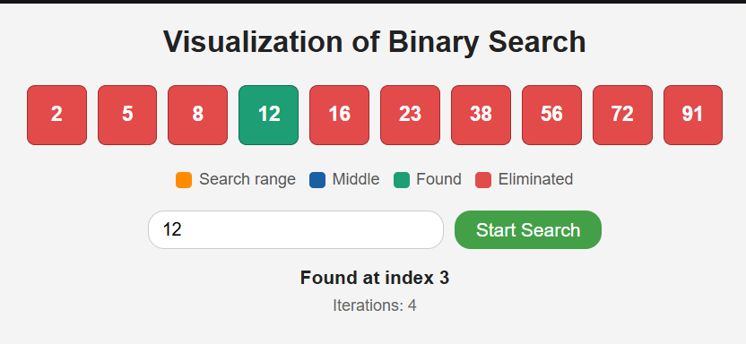